# curc_work

# Computations for depth x SWE

# 15-year graph with trend

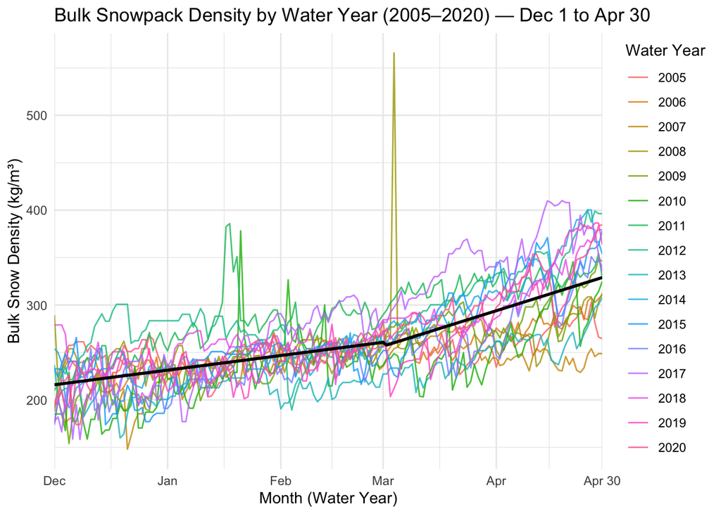

### trends over the years (for poster) with the M-P fitted line

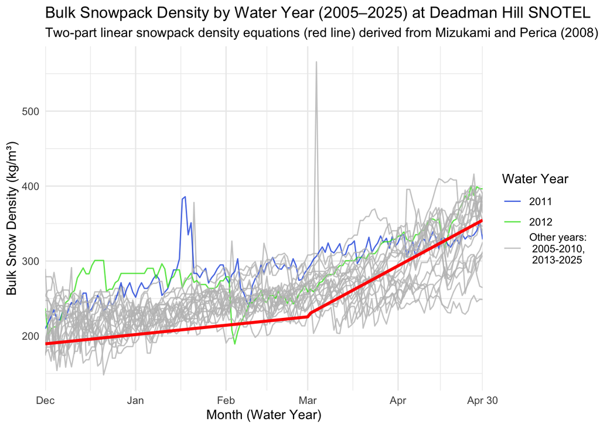

**Figure 1.** Seasonal evolution of bulk snowpack density at the Deadman Hill SNOTEL site for water years 2005–2025, restricted to December 1 through April 30. Water years 2011 and 2012 are highlighted for comparison, while all remaining years are shown in gray. The red line shows a piecewise empirical density model using 𝜌=164.7+0.4” ” 𝑡_𝑊𝑌from December 1 to March 1 and 𝜌=−90.7+2.1” ” 𝑡_𝑊𝑌from March 1 to April 30 (1).

# Daily SWE, depth, and density

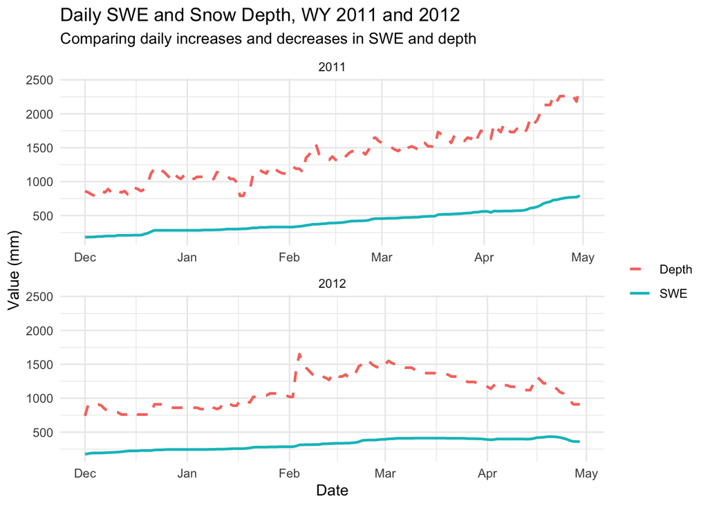

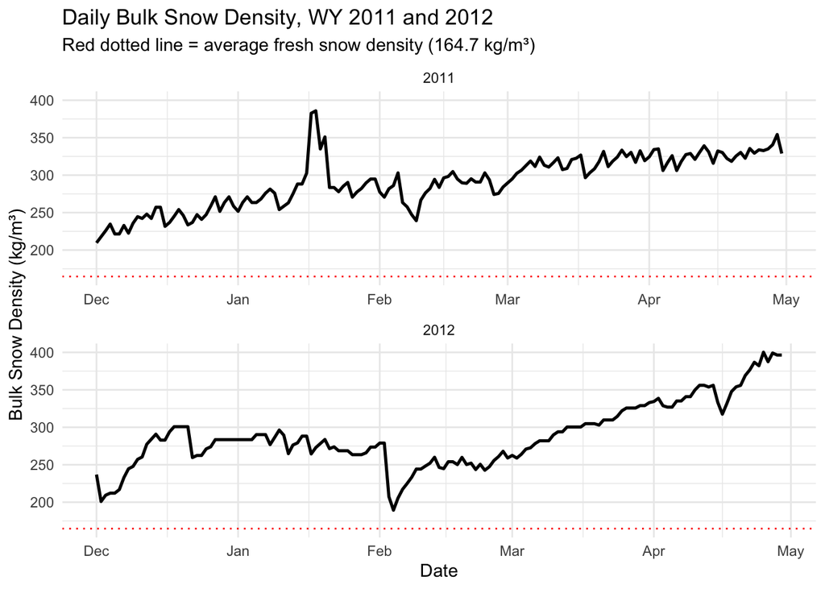

# Daily changes

## 2) Plot daily changes directly to see the pattern better

**density decreases while depth increases**, then later **depth settles back down**.

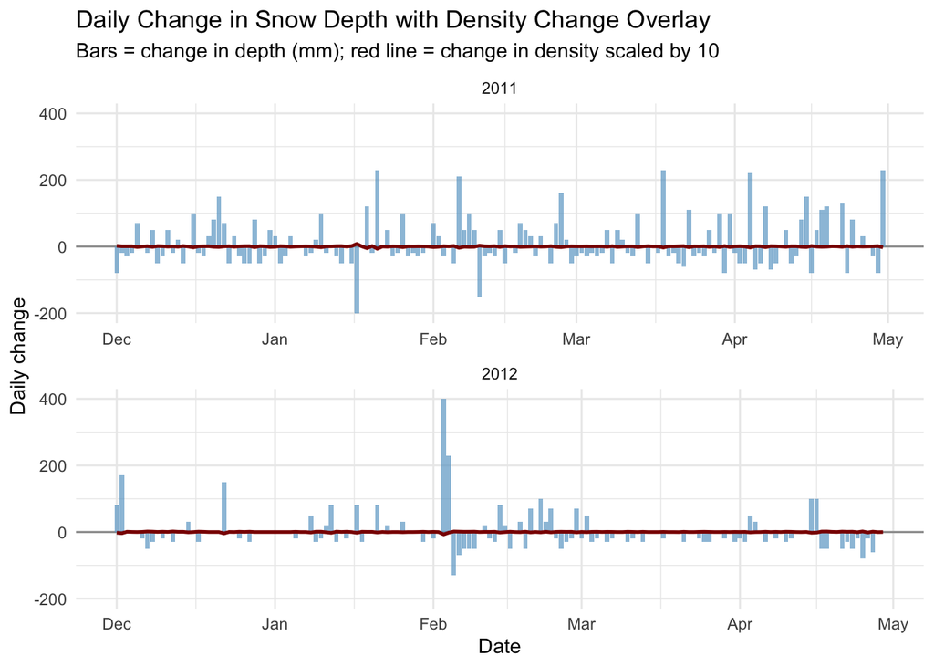

### How to read that plot

- **Large positive depth bars** with a **drop in density** suggest **new, low-density snowfall**
- After that, **depth may decline gradually** while **density rises**, which suggests **settling/compaction**
- The reverse pattern is usually less consistent with fresh snowfall

## 3) Classify likely snowfall vs settling events

compare each day’s density to a **fresh snow reference density**.

## 5) Scatterplot to distinguish snowfall vs settling

- x = **change in depth**
- y = **change in density**

That gives: - **upper left / lower right** type structure depending on process - **fresh snowfall** should often be **depth up, density down** - **settling** should often be **depth down, density up**

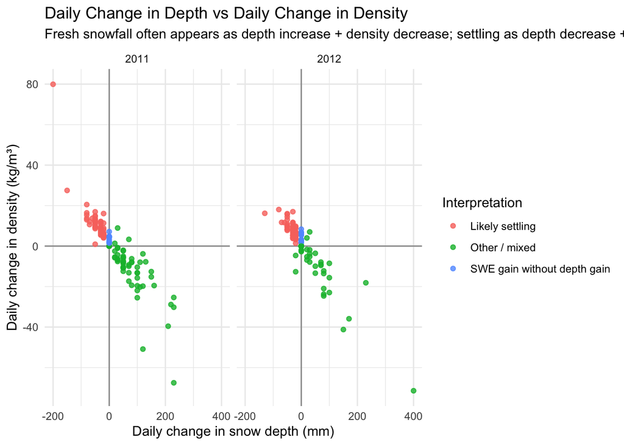

- **Precip > 0**
- **SWE increases**
- **Depth increases or stays similar**
- **Density decreases or stays near fresh snow density**

That is strong evidence for **new snowfall**

## 7) A cleaner event-based filter

This isolates the pattern:

> when density spikes down, depth spikes up, then comes down later at a different settling rate

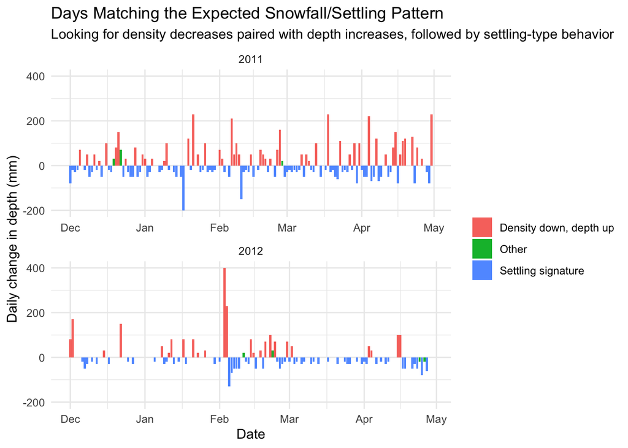

## Step-by-step: modeled density → modeled depth → daily changes → difference plot

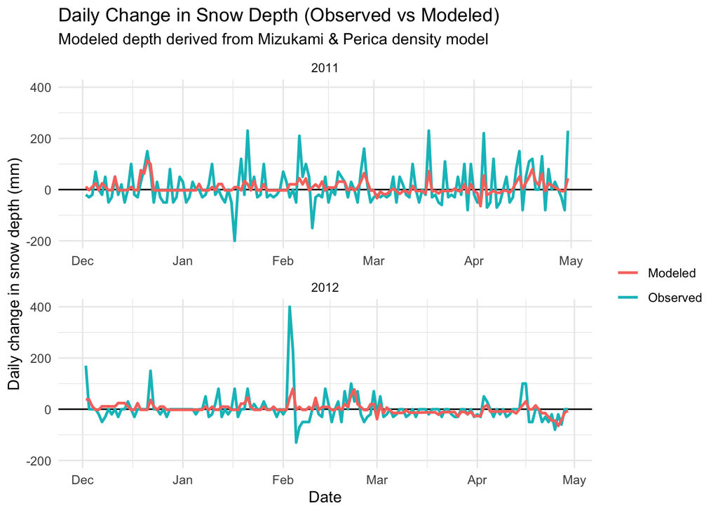

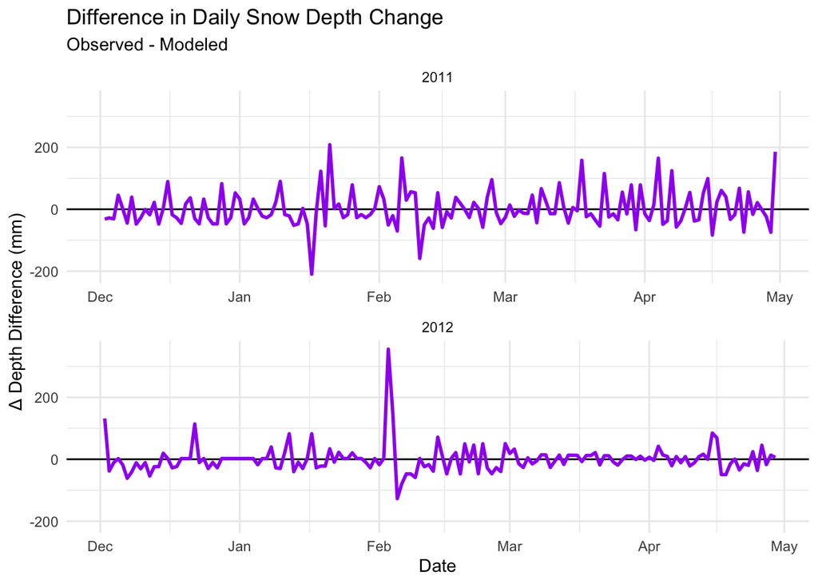